# White racial resentment blocs analysis

# Setup

```r
# devtools::install_github("coletl/blocs", dependencies = TRUE)
library(blocs)
library(dplyr)
library(tidyr)
library(kableExtra)
library(ggplot2)

boot_iters <- 1e4
set.seed(94305)

run_rmd <- function(file, echo = FALSE){
    tmp <- tempfile()
    suppressMessages(invisible(knitr::purl(file, output = tmp, documentation = 0)))
    cat("Extracted code, now evaluating...")

    source(tmp, echo = echo)
    unlink(tmp)
}
```

```r
anes <-
    readRDS("data/anes_clean.rds") %>%
    as.data.frame()

rr_yrs <- group_by(anes, year) %>% summarize(count = sum(!is.na(racialres)))

anes <-
    filter(anes,
           # observed racial resentment
           year %in% filter(rr_yrs, count > 0)$year,
           # presidential year
           year %in% seq(1988, 2020, 4)
    )
```

```r
min_rr <-
  anes %>% filter(race == "white") %>%
  pull(racialres) %>% min(na.rm = TRUE)

max_rr <-
  anes %>% filter(race == "white") %>%
  pull(racialres) %>% max(na.rm = TRUE)
```

```r
voter_wide <- readRDS("data/voter_update_clean.rds")
```

# Initial plots

## Density

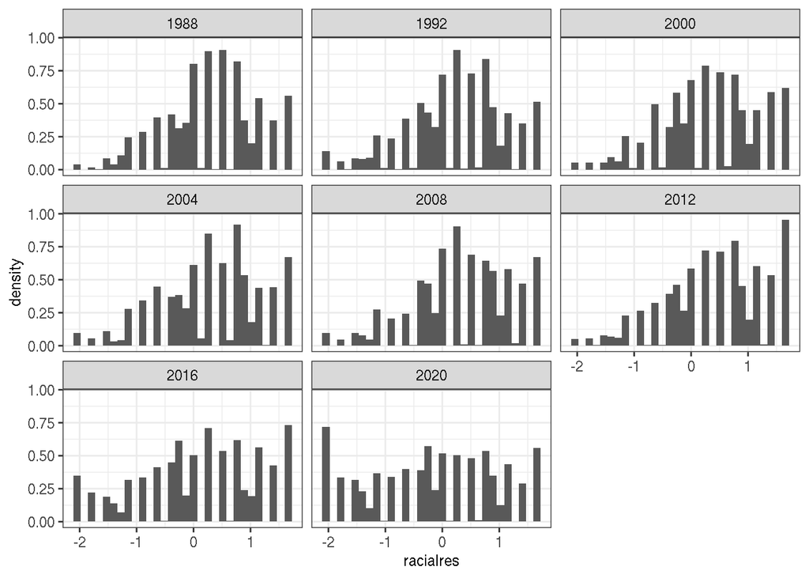

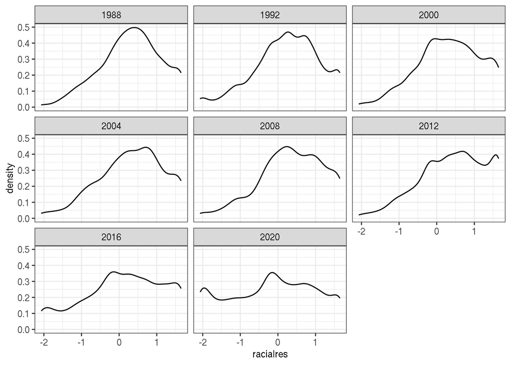

```r
g_hist <-
    filter(anes, race == "white") %>%
    ggplot() + aes(x = racialres, y = ..density..,  weight = weight) +
    geom_histogram() + facet_wrap("year") + theme_bw()

g_dens <-
    filter(anes, race == "white") %>%
    ggplot() + aes(x = racialres, y = ..density..,  weight = weight) +
    geom_density() + facet_wrap("year") + theme_bw()

g_hist; g_dens
```

## Turnout

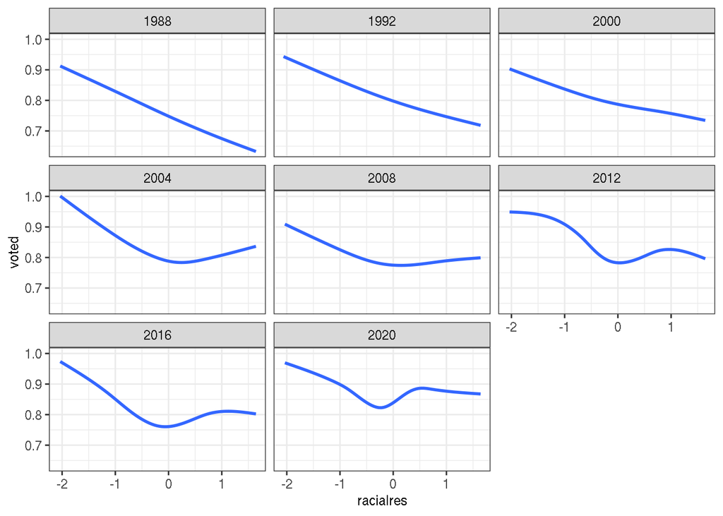

```r
g_turnout <-
    filter(anes, race == "white") %>%
    ggplot() +
    aes(x = racialres, y = voted) +
    geom_smooth(se = FALSE) + facet_wrap("year") + theme_bw()

g_turnout
```

## Vote choice

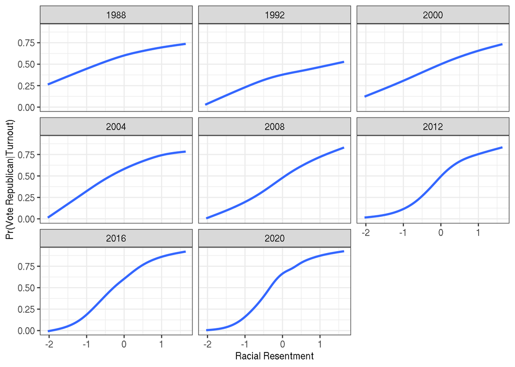

```r
g_relation <-
    filter(anes, race == "white") %>%
    ggplot() +
    aes(x = racialres, y = vote_pres_rep) +
    geom_smooth(se = FALSE) + facet_wrap("year") + theme_bw() +
    xlab('Racial Resentment') + ylab('Pr(Vote Republican|Turnout)')

g_relation
```

# Main analysis

(FIGURE 3, TABLE 3)

Analyze racial resentment of white respondents. Since `vb_continuous()` accepts only continuous variables to define voting blocs, we’ll run the analysis for white respondents only, then rescale estimates to reflect white population size.

```r
# For rescaling
probs_yr <-
    group_by(anes, year) %>%
    summarize(table =
                  wtd_table(race, weight = weight,
                            prop = TRUE, return_tibble = TRUE) %>%
                  list()
    ) %>%
    unnest(table)

white_yr <- filter(probs_yr, race == "white") %>% select(-race)
```

## Continuous resentment

```r
white_res_yrs <-
    filter(anes, race == "white") %>%
    split(., .$year) %>%
    lapply(
        \(anes_yr)
        vb_continuous(data = anes_yr,

                      indep = "racialres", dv_turnout = "voted",
                      dv_voterep = "vote_pres_rep", dv_votedem = "vote_pres_dem",
                      weight = "weight",

                      # Same range to set estimation points for all years
                      min_val = min_rr,
                      max_val = max_rr,

                      boot_iters = boot_iters
        )
    )
```

### Rescale by white pop.

```r
white_res <-
    bind_rows(white_res_yrs, .id = "year") %>%
    # white_res has only white estimates,
    left_join(white_yr, by = "year") %>%
    # Scale density and net Republican votes by prop. white
    mutate(
        across(
            c("prob", "net_rep"),
            ~ .x * prop
        ),
        # used just for rescaling
        prop = NULL
    )
```

Checks.

```r
stopifnot(nrow(white_res) == 100 * (boot_iters + 1) * n_distinct(anes$year))

# Assert that the same racialres values were used for each year
for(yr in unique(white_res$year))
    stopifnot(
        setequal(filter(white_res, year == 2012)$racialres,
                 filter(white_res, year == yr)$racialres
        )

    )
```

### Year-to-year differences

```r
white_res_diff <-
    vb_difference(vbdf = white_res, diff_col = "net_rep",
                  sort_col = "year")
```

Check year differences by tag construction.

```r
stopifnot(
    white_res_diff$comp %in%
        c("2020-2016", "2016-2012", "2012-2008", "2008-2004",
          "2004-2000", "2000-1992", "1992-1988")
)
```

### Summarize results

#### Continuous summary

```r
white_res_diff_sum <-
    vb_uncertainty(white_res_diff, "continuous",
                   estimates = c("diff_net_rep"),
                   na.rm = TRUE,
                   low_ci  = 0.025, high_ci = 0.975)
```

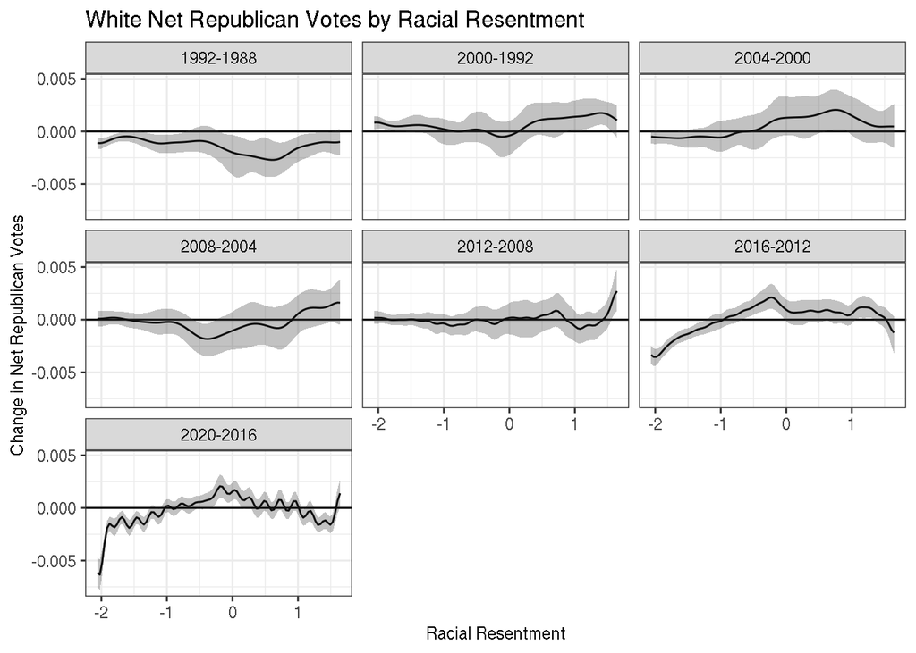

```r
p_diff_cont <-
    plot_vbdiff(white_res_diff_sum,
                y_col = "diff_net_rep_mean",
                ymin_col = "diff_net_rep_low",
                ymax_col = "diff_net_rep_high") +
    xlab('Racial Resentment') +
    ylab('Change in Net Republican Votes') +
    ggtitle('White Net Republican Votes by Racial Resentment')

p_diff_cont
```

```r
# ggsave(p_diff_cont, file='~/Dropbox/trump_voting/figs/WhiteRacialResentment.pdf')
```

2016 – 2012.

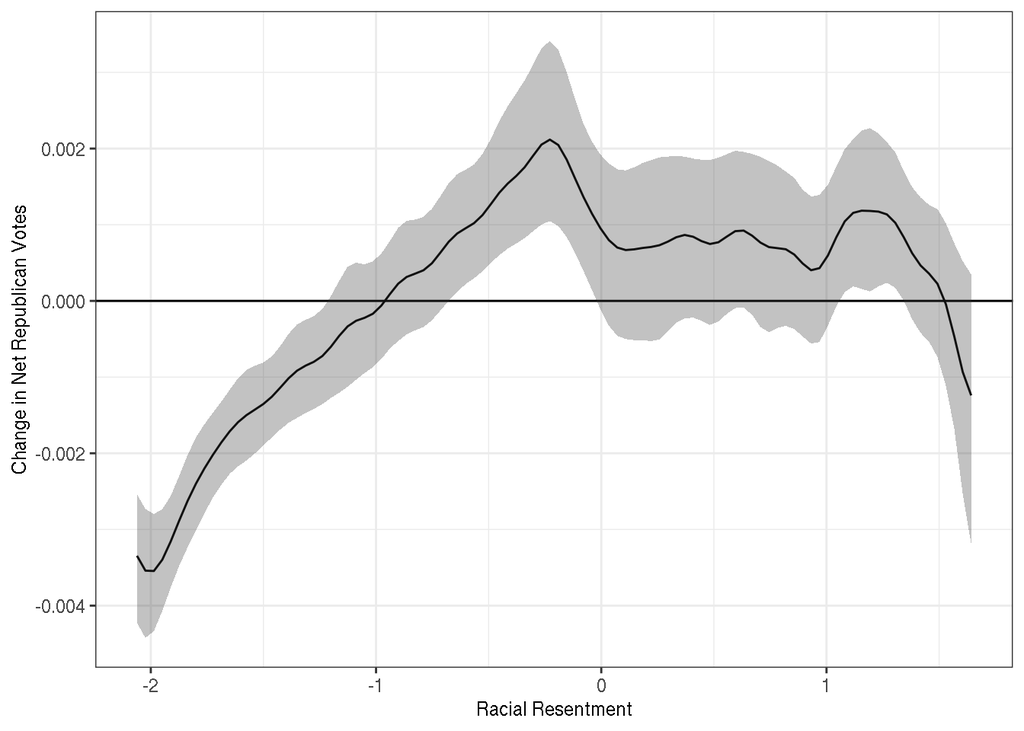

```r
p_diff_cont_2016 <-
    filter(white_res_diff_sum, comp == "2016-2012") %>%
    plot_vbdiff(y_col = "diff_net_rep_mean",
                ymin_col = "diff_net_rep_low",
                ymax_col = "diff_net_rep_high") +
    labs(x = 'Racial Resentment', y = 'Change in Net Republican Votes')  +
    theme_bw()
p_diff_cont_2016
```

```r
# ggsave(p_diff_cont_2016, file='~/Dropbox/trump_voting/figs/RacialResentment2016.pdf')
```

#### Quintile summary

Bin racial resentment into quintiles defined by 2012 levels. Then integrate point and uncertainty estimates within quintile.

```r
# Establish bins fixed at 2012 levels
rr_2012_quintile <-
    filter(anes, year == 2012, race == "white") %>%
    {
        wtd_quantile(.$racialres, weight = .$weight,
                     p = seq(0.2, 0.8, 0.2), na.rm = TRUE)
    }

rr_2012_quintile
```

```
##        20%        40%        60%        80%
## -0.2096756  0.2633666  0.7228170  1.1913351
```

```r
white_res_diff <-
    mutate(white_res_diff,
           racialres5 =
               cut(racialres, include.lowest = TRUE,
                   breaks =
                       c(
                           min(racialres, na.rm = TRUE),
                           rr_2012_quintile,
                           max(racialres, na.rm = TRUE)
                       ),
                   labels = FALSE)
    )
```

Integrate results within bin.

```r
white_res_diff_bin5sum <-
    vb_uncertainty(white_res_diff, type = "binned",
                   bin_col = "racialres5",
                   estimates = c("diff_net_rep"),
                   na.rm = TRUE)

white_res_diff_bin5sum
```

| comp | racialres5 | diff_net_rep_original | diff_net_rep_mean | diff_net_rep_median | diff_net_rep_low | diff_net_rep_high | boot_iters |
| --- | --- | --- | --- | --- | --- | --- | --- |
| 1992-1988 | 1 | -0.0483841390 | -0.0455425670 | -0.0458243403 | -0.0694751739 | -0.020688620 | 10001 |
| 1992-1988 | 2 | -0.0229616571 | -0.0258485577 | -0.0252020948 | -0.0476580261 | -0.007425381 | 10001 |
| 1992-1988 | 3 | -0.0289003771 | -0.0309396589 | -0.0312147888 | -0.0482737647 | -0.012091244 | 10001 |
| 1992-1988 | 4 | -0.0203133591 | -0.0217509976 | -0.0213854851 | -0.0359459169 | -0.009292864 | 10001 |
| 1992-1988 | 5 | -0.0158066071 | -0.0139062229 | -0.0138059839 | -0.0257198732 | -0.002512359 | 10001 |
| 2000-1992 | 1 | 0.0006673216 | 0.0168594142 | 0.0167066527 | -0.0071394536 | 0.041304243 | 10001 |
| 2000-1992 | 2 | -0.0027753627 | -0.0024595469 | -0.0022468693 | -0.0208216662 | 0.014545096 | 10001 |
| 2000-1992 | 3 | 0.0079758509 | 0.0125214233 | 0.0122196881 | -0.0029195455 | 0.029359022 | 10001 |
| 2000-1992 | 4 | 0.0158613088 | 0.0162595511 | 0.0158219953 | 0.0027581185 | 0.031998682 | 10001 |
| 2000-1992 | 5 | 0.0225152293 | 0.0201431652 | 0.0201509829 | 0.0067460154 | 0.033984319 | 10001 |

[output cut: 25 more lines]

Plot.

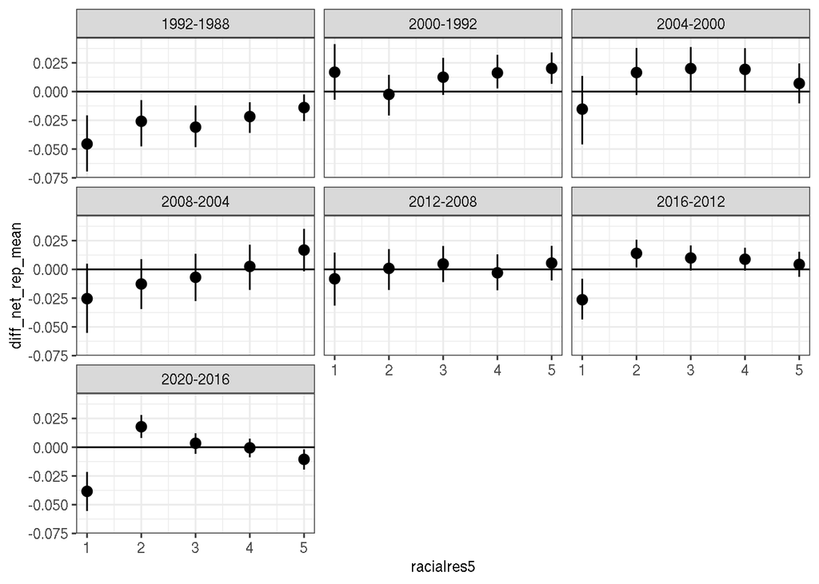

```r
p_diff5 <-
    plot_vbdiff(white_res_diff_bin5sum,
                x_col = "racialres5",
                y_col = "diff_net_rep_mean",
                ymin_col = "diff_net_rep_low",
                ymax_col = "diff_net_rep_high",
    )

p_diff5
```

Table 3, row 1.

```r
filter(white_res_diff_bin5sum, comp == "2016-2012") %>%
    setNames(.,
             gsub("diff_net_rep_", "", names(.))) %>%
    kable(digits = 3) %>% kable_styling()
```

| comp | racialres5 | original | mean | median | low | high | boot_iters |
| --- | --- | --- | --- | --- | --- | --- | --- |
| 2016-2012 | 1 | -0.023 | -0.026 | -0.027 | -0.044 | -0.008 | 10001 |
| 2016-2012 | 2 | 0.020 | 0.014 | 0.014 | 0.002 | 0.026 | 10001 |
| 2016-2012 | 3 | 0.009 | 0.010 | 0.010 | -0.001 | 0.021 | 10001 |
| 2016-2012 | 4 | 0.003 | 0.009 | 0.009 | -0.001 | 0.019 | 10001 |
| 2016-2012 | 5 | 0.004 | 0.004 | 0.004 | -0.006 | 0.015 | 10001 |

#### Quartile summary

Bin racial resentment into QUARTILES defined by 2012 levels. Then integrate point and uncertainty estimates within quintile.

```r
# Establish bins fixed at 2012 levels
rr_2012_quartile <-
    filter(anes, year == 2012, race == "white") %>%
    {
        wtd_quantile(.$racialres, weight = .$weight,
                     p = seq(0.25, 0.75, 0.25), na.rm = TRUE)
    }

rr_2012_quartile
```

```
##        25%        50%        75%
## -0.1955943  0.4941053  1.1822674
```

```r
white_res_diff <-
    mutate(white_res_diff,
           racialres4 =
               cut(racialres, include.lowest = TRUE,
                   breaks =
                       c(
                           min(racialres, na.rm = TRUE),
                           rr_2012_quartile,
                           max(racialres, na.rm = TRUE)
                       ),
                   labels = FALSE)
    )
```

Integrate results within bin.

```r
white_res_diff_bin4sum <-
    vb_uncertainty(white_res_diff, type = "binned",
                   bin_col = "racialres4",
                   estimates = c("diff_net_rep"),
                   na.rm = TRUE)

white_res_diff_bin4sum
```

| comp | racialres4 | diff_net_rep_original | diff_net_rep_mean | diff_net_rep_median | diff_net_rep_low | diff_net_rep_high | boot_iters |
| --- | --- | --- | --- | --- | --- | --- | --- |
| 1992-1988 | 1 | -0.0483841390 | -0.0455425670 | -0.0458243403 | -0.0694751739 | -0.020688620 | 10001 |
| 1992-1988 | 2 | -0.0372094936 | -0.0407391525 | -0.0401977252 | -0.0655160458 | -0.018263987 | 10001 |
| 1992-1988 | 3 | -0.0349658996 | -0.0378000616 | -0.0376146847 | -0.0572462890 | -0.018621996 | 10001 |
| 1992-1988 | 4 | -0.0158066071 | -0.0139062229 | -0.0138059839 | -0.0257198732 | -0.002512359 | 10001 |
| 2000-1992 | 1 | 0.0006673216 | 0.0168594142 | 0.0167066527 | -0.0071394536 | 0.041304243 | 10001 |
| 2000-1992 | 2 | -0.0001433094 | 0.0029219716 | 0.0028104231 | -0.0189050944 | 0.025077425 | 10001 |
| 2000-1992 | 3 | 0.0212051063 | 0.0233994559 | 0.0231190024 | 0.0038206540 | 0.044297285 | 10001 |
| 2000-1992 | 4 | 0.0225152293 | 0.0201431652 | 0.0201509829 | 0.0067460154 | 0.033984319 | 10001 |
| 2004-2000 | 1 | 0.0051899067 | -0.0152850853 | -0.0148856478 | -0.0459516485 | 0.013628686 | 10001 |
| 2004-2000 | 2 | 0.0297064181 | 0.0253713264 | 0.0251483610 | -0.0012449992 | 0.053122579 | 10001 |

[output cut: 18 more lines]

Plot.

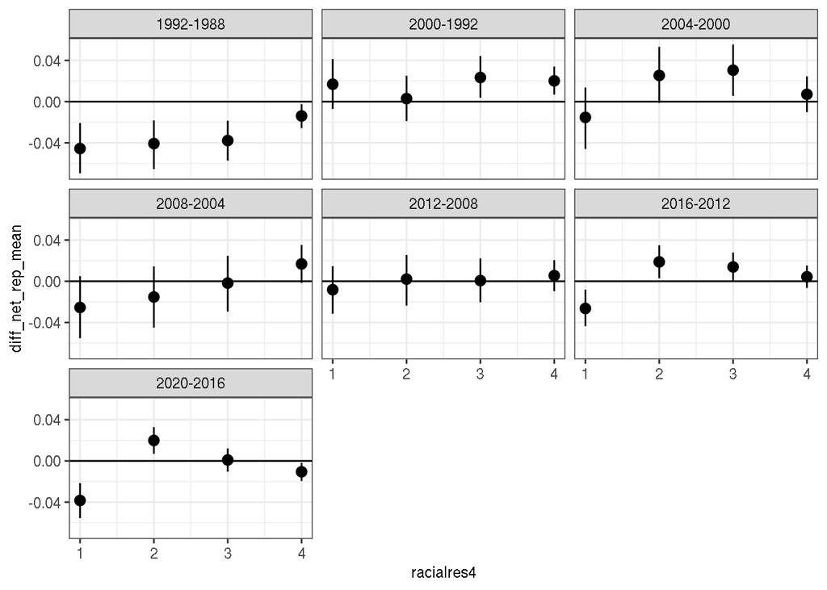

```r
p_diff4 <-
    plot_vbdiff(white_res_diff_bin4sum,
                x_col = "racialres4",
                y_col = "diff_net_rep_mean",
                ymin_col = "diff_net_rep_low",
                ymax_col = "diff_net_rep_high",
    )

p_diff4
```

Table 3, row 1.

```r
filter(white_res_diff_bin4sum, comp == "2016-2012") %>%
    setNames(.,
             gsub("diff_net_rep_", "", names(.))) %>%
    kable(digits = 3) %>% kable_styling()
```

| comp | racialres4 | original | mean | median | low | high | boot_iters |
| --- | --- | --- | --- | --- | --- | --- | --- |
| 2016-2012 | 1 | -0.023 | -0.026 | -0.027 | -0.044 | -0.008 | 10001 |
| 2016-2012 | 2 | 0.025 | 0.019 | 0.019 | 0.003 | 0.035 | 10001 |
| 2016-2012 | 3 | 0.007 | 0.014 | 0.014 | 0.000 | 0.028 | 10001 |
| 2016-2012 | 4 | 0.004 | 0.004 | 0.004 | -0.006 | 0.015 | 10001 |

## Discretized resentment

Bin racial resentment into 2012 quintiles, quartiles before analysis.

```r
anes <-
    mutate(anes,
           racialres_bin5 =
               cut(racialres,
                   breaks = c(min(racialres, na.rm = TRUE),
                              rr_2012_quintile,
                              max(racialres, na.rm = TRUE)
                   ),
                   include.lowest = TRUE, labels = FALSE
               ) %>% factor(ordered = TRUE),

           racialres_bin4 =
               cut(racialres,
                   breaks = c(min(racialres, na.rm = TRUE),
                              rr_2012_quartile,
                              max(racialres, na.rm = TRUE)
                   ),
                   include.lowest = TRUE, labels = FALSE
               ) %>% factor(ordered = TRUE)
    )
```

```r
resbin4 <-
    anes %>%
    filter(race == "white") %>%
    split(., .$year) %>%
    lapply(
        \(anes_yr)
        vb_discrete(data = anes_yr,
                    indep = c("racialres_bin4"),
                    dv_turnout = "voted",
                    dv_voterep = "vote_pres_rep",
                    dv_votedem = "vote_pres_dem",
                    weight = "weight",

                    boot_iters = boot_iters,
                    check_discrete = FALSE
        )
    ) %>%

    bind_rows(.id = "year") %>%

    # Rescale density and net votes by proportion white in tot. pop.
    # since we subset to white respondents
    left_join(white_yr, by = "year") %>%
    # Scale density and net Republican votes by prop. white
    mutate(
        across(
            c("prob", "net_rep"),
            ~ .x * prop
        ),
        # used just for rescaling
        prop = NULL
    )
```

```r
resbin5 <-
    anes %>%
    filter(race == "white") %>%
    split(., .$year) %>%
    lapply(
        \(anes_yr)
        vb_discrete(anes_yr,
                    indep = c("racialres_bin5"),
                    dv_turnout = "voted",
                    dv_voterep = "vote_pres_rep",
                    dv_votedem = "vote_pres_dem",
                    weight = "weight",

                    boot_iters = boot_iters,
                    check_discrete = FALSE
        )
    ) %>%

    bind_rows(.id = "year") %>%

    # Rescale density and net votes by proportion white in tot. pop.
    # since we subset to white respondents
    left_join(white_yr, by = "year") %>%
    # Scale density and net Republican votes by prop. white
    mutate(
        across(
            c("prob", "net_rep"),
            ~ .x * prop
        ),
        # used just for rescaling
        prop = NULL
    )
```

Check, allowing for resampling variability.

```r
resbin5 %>%
    group_by(year, resample) %>%
    summarize(race_tot = sum(prob),
              ave_turnout = mean(pr_turnout)) %>%
    {
        stopifnot(
            all(
                between(.$race_tot, 0.4, 1),
                between(.$ave_turnout, 0.5, 1)
                )
            )
    }
resbin4 %>%
    group_by(year, resample) %>%
    summarize(race_tot = sum(prob),
              ave_turnout = mean(pr_turnout)) %>%
    {
        stopifnot(
            all(
                between(.$race_tot, 0.4, 1),
                between(.$ave_turnout, 0.5, 1)
                )
            )
    }
```

### Quintiled racial resentment

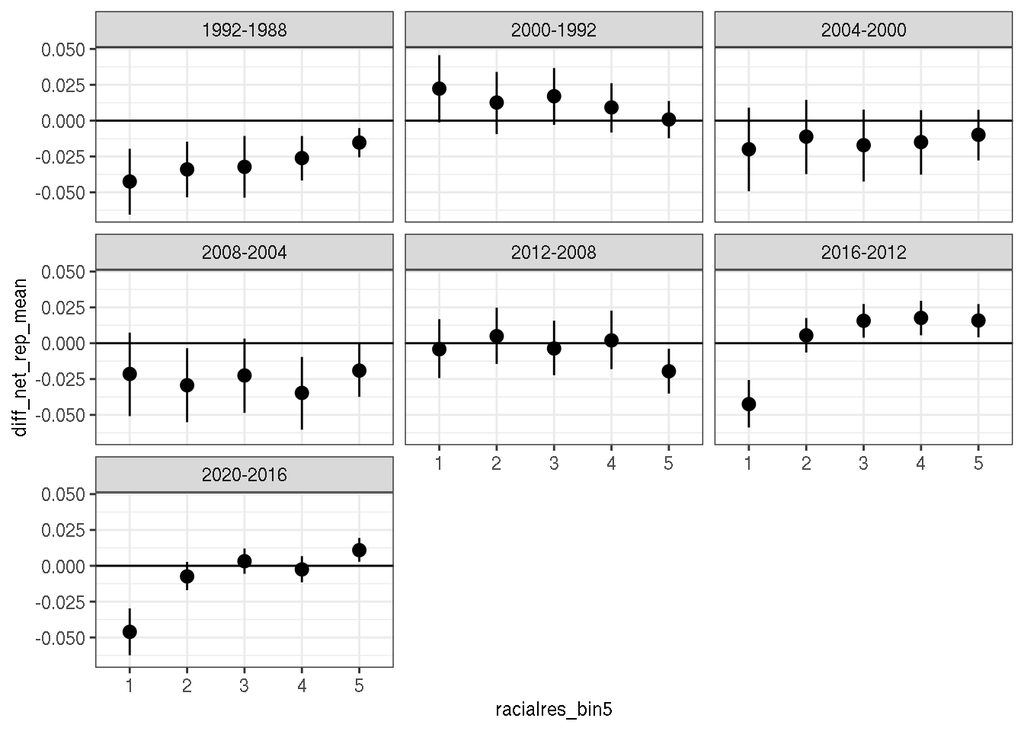

```r
white_resbin5_diff <-
    resbin5 %>%
    vb_difference(diff_col = "net_rep")

white_resbin5_diff_sum <-
    vb_uncertainty(white_resbin5_diff, type = "discrete",
                   estimates = "diff_net_rep")


p_diff5 <-
    plot_vbdiff(white_resbin5_diff_sum,
                x_col = "racialres_bin5",
                y_col = "diff_net_rep_mean",
                ymin_col = "diff_net_rep_low",
                ymax_col = "diff_net_rep_high"
    )

p_diff5
```

### Quartiled racial resentment

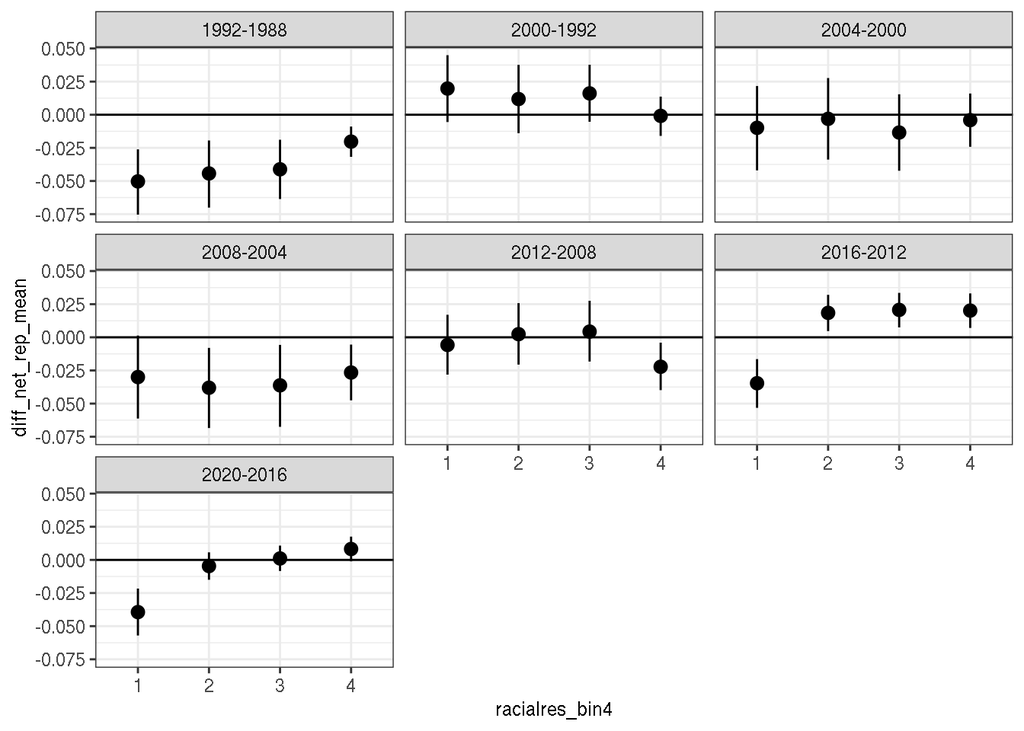

```r
white_resbin4_diff <-
    resbin4 %>%
    vb_difference(diff_col = "net_rep")

white_resbin4_diff_sum <-
    vb_uncertainty(white_resbin4_diff, type = "discrete",
                   estimates = "diff_net_rep")


p_diff4 <-
    plot_vbdiff(white_resbin4_diff_sum,
                x_col = "racialres_bin4",
                y_col = "diff_net_rep_mean",
                ymin_col = "diff_net_rep_low",
                ymax_col = "diff_net_rep_high",
    )

p_diff4
```

## Results

```r
rbind(
  data.frame(analysis = "Cont, quin summary", white_res_diff_bin5sum) %>%
    filter(comp %in% c("2016-2012", "2020-2016")) %>% rename_with(~ "racialres_lvl", matches("racialres")),
  data.frame(analysis = "Disc quin", white_resbin5_diff_sum) %>%
    filter(comp == "2016-2012") %>% rename_with(~ "racialres_lvl", matches("racialres")),
  data.frame(analysis = "Cont, quar sum", white_res_diff_bin4sum) %>%
    filter(comp == "2016-2012") %>% rename_with(~ "racialres_lvl", matches("racialres")),
  data.frame(analysis = "Disc quar", white_resbin4_diff_sum) %>%
    filter(comp == "2016-2012") %>% rename_with(~ "racialres_lvl", matches("racialres"))
) %>%
  dplyr::select(all_of(
    c("analysis", "comp", "diff_net_rep_mean",
                "diff_net_rep_low", "diff_net_rep_high")
  )) %>%
  knitr::kable(digits = 3) %>% kable_styling()
```

| analysis | comp | diff_net_rep_mean | diff_net_rep_low | diff_net_rep_high |
| --- | --- | --- | --- | --- |
| Cont, quin summary | 2016-2012 | -0.026 | -0.044 | -0.008 |
| Cont, quin summary | 2016-2012 | 0.014 | 0.002 | 0.026 |
| Cont, quin summary | 2016-2012 | 0.010 | -0.001 | 0.021 |
| Cont, quin summary | 2016-2012 | 0.009 | -0.001 | 0.019 |
| Cont, quin summary | 2016-2012 | 0.004 | -0.006 | 0.015 |
| Cont, quin summary | 2020-2016 | -0.038 | -0.055 | -0.021 |
| Cont, quin summary | 2020-2016 | 0.018 | 0.008 | 0.028 |
| Cont, quin summary | 2020-2016 | 0.003 | -0.006 | 0.012 |
| Cont, quin summary | 2020-2016 | -0.001 | -0.009 | 0.007 |
| Cont, quin summary | 2020-2016 | -0.011 | -0.019 | -0.002 |
| Disc quin | 2016-2012 | -0.043 | -0.059 | -0.026 |
| Disc quin | 2016-2012 | 0.005 | -0.006 | 0.018 |
| Disc quin | 2016-2012 | 0.016 | 0.004 | 0.027 |
| Disc quin | 2016-2012 | 0.018 | 0.006 | 0.030 |
| Disc quin | 2016-2012 | 0.016 | 0.004 | 0.027 |
| Cont, quar sum | 2016-2012 | -0.026 | -0.044 | -0.008 |
| Cont, quar sum | 2016-2012 | 0.019 | 0.003 | 0.035 |
| Cont, quar sum | 2016-2012 | 0.014 | 0.000 | 0.028 |
| Cont, quar sum | 2016-2012 | 0.004 | -0.006 | 0.015 |
| Disc quar | 2016-2012 | -0.035 | -0.053 | -0.016 |
| Disc quar | 2016-2012 | 0.018 | 0.005 | 0.032 |
| Disc quar | 2016-2012 | 0.021 | 0.007 | 0.034 |
| Disc quar | 2016-2012 | 0.020 | 0.007 | 0.033 |

# Robustness

(TABLE 3)

Check patterns in subgroups. Because we drop the non-white respondents from each data set, we need to rescale the density and net-votes estimates.

```r
robust_years <- c(2012, 2016)
robust_results <- list()

pop_count <-
  group_by(anes, year) %>%
  count(wt = weight)
```

## Partisanship

### White Republicans’ resentment

```r
anes_sub <-
    filter(anes,

           pid3 == "rep", race == "white",

           year %in% robust_years
    )

sub_tag <- "White GOP"
```

Run continuous voting bloc analysis.

```r
lvbdf <-
    anes_sub %>%
    split(., .$year) %>%
    lapply(

        vb_continuous,

        indep = "racialres", dv_turnout = "voted",
        dv_voterep = "vote_pres_rep", dv_votedem = "vote_pres_dem",
        weight = "weight",

        # Same range to set estimation points for all years
        min_val = min_rr,
        max_val = max_rr,

        boot_iters = boot_iters
    )
```

Rescale by white population.

```r
sub_rescale <-
    count(anes_sub, year, wt = weight) %>%
    left_join(pop_count, by = "year", suffix = c("_sub", "_pop")) %>%
    mutate(subgrp_prob = n_sub / n_pop,
           n_sub = NULL, n_pop = NULL)

sub_vbdf <-
    bind_rows(lvbdf, .id = "year") %>%
    left_join(sub_rescale, by = "year") %>%
    # Scale density, net Republican votes estimates by prop. white
    mutate(
        across(
            matches("^prob|^net_rep"),
            ~ .x * subgrp_prob,
            .names = "{.col}_rescale"
        )
    )
```

```r
stopifnot(nrow(sub_vbdf) == 100 * (boot_iters + 1) * n_distinct(anes_sub$year))

# Assert that the same racialres values were used for each year
for(yr in unique(anes_sub$year))
    stopifnot(
        setequal(filter(sub_vbdf, year == 2012)$racialres,
                 filter(sub_vbdf, year == yr)$racialres
        )

    )
```

Calculate year-to-year differences.

```r
sub_vbdiff <-
    vb_difference(vbdf = sub_vbdf, diff_col = "net_rep_rescale",
                  sort_col = "year")
```

Integrate results within quintile.

```r
sub_vbdiff <-
    mutate(sub_vbdiff,
           racialres5 =
               cut(racialres, include.lowest = TRUE,
                   breaks =
                       c(
                           min(racialres, na.rm = TRUE),
                           rr_2012_quintile,
                           max(racialres, na.rm = TRUE)
                       ),
                   labels = FALSE)
           )

sub_sum <-
    vb_uncertainty(sub_vbdiff, type = "binned",
                   bin_col = "racialres5",
                   estimates = c("diff_net_rep_rescale"),
                   na.rm = TRUE)
```

```r
robust_results[[sub_tag]] <- sub_sum
```

### White Democrats’ resentment

```r
anes_sub <-
    filter(anes,

           pid3 == "dem", race == "white",

           year %in% robust_years
    )

sub_tag <- "White Dem"
```

Run continuous voting bloc analysis.

```r
lvbdf <-
    anes_sub %>%
    split(., .$year) %>%
    lapply(

        vb_continuous,

        indep = "racialres", dv_turnout = "voted",
        dv_voterep = "vote_pres_rep", dv_votedem = "vote_pres_dem",
        weight = "weight",

        # Same range to set estimation points for all years
        min_val = min_rr,
        max_val = max_rr,

        boot_iters = boot_iters
    )
```

Rescale by white population.

```r
sub_rescale <-
    count(anes_sub, year, wt = weight) %>%
    left_join(pop_count, by = "year", suffix = c("_sub", "_pop")) %>%
    mutate(subgrp_prob = n_sub / n_pop,
           n_sub = NULL, n_pop = NULL)

sub_vbdf <-
    bind_rows(lvbdf, .id = "year") %>%
    left_join(sub_rescale, by = "year") %>%
    # Scale density, net Republican votes estimates by prop. white
    mutate(
        across(
            matches("^prob|^net_rep"),
            ~ .x * subgrp_prob,
            .names = "{.col}_rescale"
        )
    )
```

```r
stopifnot(nrow(sub_vbdf) == 100 * (boot_iters + 1) * n_distinct(anes_sub$year))

# Assert that the same racialres values were used for each year
for(yr in unique(anes_sub$year))
    stopifnot(
        setequal(filter(sub_vbdf, year == 2012)$racialres,
                 filter(sub_vbdf, year == yr)$racialres
        )

    )
```

Calculate year-to-year differences.

```r
sub_vbdiff <-
    vb_difference(vbdf = sub_vbdf, diff_col = "net_rep_rescale",
                  sort_col = "year")
```

Integrate results within quintile.

```r
sub_vbdiff <-
    mutate(sub_vbdiff,
           racialres5 =
               cut(racialres, include.lowest = TRUE,
                   breaks =
                       c(
                           min(racialres, na.rm = TRUE),
                           rr_2012_quintile,
                           max(racialres, na.rm = TRUE)
                       ),
                   labels = FALSE)
           )

sub_sum <-
    vb_uncertainty(sub_vbdiff, type = "binned",
                   bin_col = "racialres5",
                   estimates = c("diff_net_rep_rescale"),
                   na.rm = TRUE)
```

```r
robust_results[[sub_tag]] <- sub_sum
```

### White Independents’ resentment

```r
anes_sub <-
    filter(anes,

           pid3 == "indep", race == "white",

           year %in% robust_years
    )

sub_tag <- "White Ind"
```

Run continuous voting bloc analysis.

```r
lvbdf <-
    anes_sub %>%
    split(., .$year) %>%
    lapply(

        vb_continuous,

        indep = "racialres", dv_turnout = "voted",
        dv_voterep = "vote_pres_rep", dv_votedem = "vote_pres_dem",
        weight = "weight",

        # Same range to set estimation points for all years
        min_val = min_rr,
        max_val = max_rr,

        boot_iters = boot_iters
    )
```

Rescale by white population.

```r
sub_rescale <-
    count(anes_sub, year, wt = weight) %>%
    left_join(pop_count, by = "year", suffix = c("_sub", "_pop")) %>%
    mutate(subgrp_prob = n_sub / n_pop,
           n_sub = NULL, n_pop = NULL)

sub_vbdf <-
    bind_rows(lvbdf, .id = "year") %>%
    left_join(sub_rescale, by = "year") %>%
    # Scale density, net Republican votes estimates by prop. white
    mutate(
        across(
            matches("^prob|^net_rep"),
            ~ .x * subgrp_prob,
            .names = "{.col}_rescale"
        )
    )
```

```r
stopifnot(nrow(sub_vbdf) == 100 * (boot_iters + 1) * n_distinct(anes_sub$year))

# Assert that the same racialres values were used for each year
for(yr in unique(anes_sub$year))
    stopifnot(
        setequal(filter(sub_vbdf, year == 2012)$racialres,
                 filter(sub_vbdf, year == yr)$racialres
        )

    )
```

Calculate year-to-year differences.

```r
sub_vbdiff <-
    vb_difference(vbdf = sub_vbdf, diff_col = "net_rep_rescale",
                  sort_col = "year")
```

Integrate results within quintile.

```r
sub_vbdiff <-
    mutate(sub_vbdiff,
           racialres5 =
               cut(racialres, include.lowest = TRUE,
                   breaks =
                       c(
                           min(racialres, na.rm = TRUE),
                           rr_2012_quintile,
                           max(racialres, na.rm = TRUE)
                       ),
                   labels = FALSE)
           )

sub_sum <-
    vb_uncertainty(sub_vbdiff, type = "binned",
                   bin_col = "racialres5",
                   estimates = c("diff_net_rep_rescale"),
                   na.rm = TRUE)
```

```r
robust_results[[sub_tag]] <- sub_sum
```

## Obama voters

```r
anes_sub <-
  filter(anes,
         race == "white",
         last_voted == 1, last_vote_pres == "dem",
         year %in% robust_years)

sub_tag <- "White Obama Voters"
```

Run continuous voting bloc analysis.

```r
lvbdf <-
    anes_sub %>%
    split(., .$year) %>%
    lapply(

        vb_continuous,

        indep = "racialres", dv_turnout = "voted",
        dv_voterep = "vote_pres_rep", dv_votedem = "vote_pres_dem",
        weight = "weight",

        # Same range to set estimation points for all years
        min_val = min_rr,
        max_val = max_rr,

        boot_iters = boot_iters
    )
```

Rescale by white population.

```r
sub_rescale <-
    count(anes_sub, year, wt = weight) %>%
    left_join(pop_count, by = "year", suffix = c("_sub", "_pop")) %>%
    mutate(subgrp_prob = n_sub / n_pop,
           n_sub = NULL, n_pop = NULL)

sub_vbdf <-
    bind_rows(lvbdf, .id = "year") %>%
    left_join(sub_rescale, by = "year") %>%
    # Scale density, net Republican votes estimates by prop. white
    mutate(
        across(
            matches("^prob|^net_rep"),
            ~ .x * subgrp_prob,
            .names = "{.col}_rescale"
        )
    )
```

```r
stopifnot(nrow(sub_vbdf) == 100 * (boot_iters + 1) * n_distinct(anes_sub$year))

# Assert that the same racialres values were used for each year
for(yr in unique(anes_sub$year))
    stopifnot(
        setequal(filter(sub_vbdf, year == 2012)$racialres,
                 filter(sub_vbdf, year == yr)$racialres
        )

    )
```

Calculate year-to-year differences.

```r
sub_vbdiff <-
    vb_difference(vbdf = sub_vbdf, diff_col = "net_rep_rescale",
                  sort_col = "year")
```

Integrate results within quintile.

```r
sub_vbdiff <-
    mutate(sub_vbdiff,
           racialres5 =
               cut(racialres, include.lowest = TRUE,
                   breaks =
                       c(
                           min(racialres, na.rm = TRUE),
                           rr_2012_quintile,
                           max(racialres, na.rm = TRUE)
                       ),
                   labels = FALSE)
           )

sub_sum <-
    vb_uncertainty(sub_vbdiff, type = "binned",
                   bin_col = "racialres5",
                   estimates = c("diff_net_rep_rescale"),
                   na.rm = TRUE)
```

```r
robust_results[[sub_tag]] <- sub_sum
```

## Demographics

### Low education

```r
anes_sub <-
    filter(anes,

           educ == "HS or less", race == "white",

           year %in% robust_years
    )

sub_tag <- "White Low Educ"
```

Run continuous voting bloc analysis.

```r
lvbdf <-
    anes_sub %>%
    split(., .$year) %>%
    lapply(

        vb_continuous,

        indep = "racialres", dv_turnout = "voted",
        dv_voterep = "vote_pres_rep", dv_votedem = "vote_pres_dem",
        weight = "weight",

        # Same range to set estimation points for all years
        min_val = min_rr,
        max_val = max_rr,

        boot_iters = boot_iters
    )
```

Rescale by white population.

```r
sub_rescale <-
    count(anes_sub, year, wt = weight) %>%
    left_join(pop_count, by = "year", suffix = c("_sub", "_pop")) %>%
    mutate(subgrp_prob = n_sub / n_pop,
           n_sub = NULL, n_pop = NULL)

sub_vbdf <-
    bind_rows(lvbdf, .id = "year") %>%
    left_join(sub_rescale, by = "year") %>%
    # Scale density, net Republican votes estimates by prop. white
    mutate(
        across(
            matches("^prob|^net_rep"),
            ~ .x * subgrp_prob,
            .names = "{.col}_rescale"
        )
    )
```

```r
stopifnot(nrow(sub_vbdf) == 100 * (boot_iters + 1) * n_distinct(anes_sub$year))

# Assert that the same racialres values were used for each year
for(yr in unique(anes_sub$year))
    stopifnot(
        setequal(filter(sub_vbdf, year == 2012)$racialres,
                 filter(sub_vbdf, year == yr)$racialres
        )

    )
```

Calculate year-to-year differences.

```r
sub_vbdiff <-
    vb_difference(vbdf = sub_vbdf, diff_col = "net_rep_rescale",
                  sort_col = "year")
```

Integrate results within quintile.

```r
sub_vbdiff <-
    mutate(sub_vbdiff,
           racialres5 =
               cut(racialres, include.lowest = TRUE,
                   breaks =
                       c(
                           min(racialres, na.rm = TRUE),
                           rr_2012_quintile,
                           max(racialres, na.rm = TRUE)
                       ),
                   labels = FALSE)
           )

sub_sum <-
    vb_uncertainty(sub_vbdiff, type = "binned",
                   bin_col = "racialres5",
                   estimates = c("diff_net_rep_rescale"),
                   na.rm = TRUE)
```

```r
robust_results[[sub_tag]] <- sub_sum
```

### Low income

```r
anes_sub <-
    filter(anes,

           faminc_terc == "1st", race == "white",

           year %in% robust_years
    )

sub_tag <- "White Low Income"
```

Run continuous voting bloc analysis.

```r
lvbdf <-
    anes_sub %>%
    split(., .$year) %>%
    lapply(

        vb_continuous,

        indep = "racialres", dv_turnout = "voted",
        dv_voterep = "vote_pres_rep", dv_votedem = "vote_pres_dem",
        weight = "weight",

        # Same range to set estimation points for all years
        min_val = min_rr,
        max_val = max_rr,

        boot_iters = boot_iters
    )
```

Rescale by white population.

```r
sub_rescale <-
    count(anes_sub, year, wt = weight) %>%
    left_join(pop_count, by = "year", suffix = c("_sub", "_pop")) %>%
    mutate(subgrp_prob = n_sub / n_pop,
           n_sub = NULL, n_pop = NULL)

sub_vbdf <-
    bind_rows(lvbdf, .id = "year") %>%
    left_join(sub_rescale, by = "year") %>%
    # Scale density, net Republican votes estimates by prop. white
    mutate(
        across(
            matches("^prob|^net_rep"),
            ~ .x * subgrp_prob,
            .names = "{.col}_rescale"
        )
    )
```

```r
stopifnot(nrow(sub_vbdf) == 100 * (boot_iters + 1) * n_distinct(anes_sub$year))

# Assert that the same racialres values were used for each year
for(yr in unique(anes_sub$year))
    stopifnot(
        setequal(filter(sub_vbdf, year == 2012)$racialres,
                 filter(sub_vbdf, year == yr)$racialres
        )

    )
```

Calculate year-to-year differences.

```r
sub_vbdiff <-
    vb_difference(vbdf = sub_vbdf, diff_col = "net_rep_rescale",
                  sort_col = "year")
```

Integrate results within quintile.

```r
sub_vbdiff <-
    mutate(sub_vbdiff,
           racialres5 =
               cut(racialres, include.lowest = TRUE,
                   breaks =
                       c(
                           min(racialres, na.rm = TRUE),
                           rr_2012_quintile,
                           max(racialres, na.rm = TRUE)
                       ),
                   labels = FALSE)
           )

sub_sum <-
    vb_uncertainty(sub_vbdiff, type = "binned",
                   bin_col = "racialres5",
                   estimates = c("diff_net_rep_rescale"),
                   na.rm = TRUE)
```

```r
robust_results[[sub_tag]] <- sub_sum
```

## 2020-2012

```r
anes_sub <-
    filter(anes,

           race == "white",

           year %in% c(2012, 2020)
    )

sub_tag <- "White 2020"
```

Run continuous voting bloc analysis.

```r
lvbdf <-
    anes_sub %>%
    split(., .$year) %>%
    lapply(

        vb_continuous,

        indep = "racialres", dv_turnout = "voted",
        dv_voterep = "vote_pres_rep", dv_votedem = "vote_pres_dem",
        weight = "weight",

        # Same range to set estimation points for all years
        min_val = min_rr,
        max_val = max_rr,

        boot_iters = boot_iters
    )
```

Rescale by white population.

```r
sub_rescale <-
    count(anes_sub, year, wt = weight) %>%
    left_join(pop_count, by = "year", suffix = c("_sub", "_pop")) %>%
    mutate(subgrp_prob = n_sub / n_pop,
           n_sub = NULL, n_pop = NULL)

sub_vbdf <-
    bind_rows(lvbdf, .id = "year") %>%
    left_join(sub_rescale, by = "year") %>%
    # Scale density, net Republican votes estimates by prop. white
    mutate(
        across(
            matches("^prob|^net_rep"),
            ~ .x * subgrp_prob,
            .names = "{.col}_rescale"
        )
    )
```

```r
stopifnot(nrow(sub_vbdf) == 100 * (boot_iters + 1) * n_distinct(anes_sub$year))

# Assert that the same racialres values were used for each year
for(yr in unique(anes_sub$year))
    stopifnot(
        setequal(filter(sub_vbdf, year == 2012)$racialres,
                 filter(sub_vbdf, year == yr)$racialres
        )

    )
```

Calculate year-to-year differences.

```r
sub_vbdiff <-
    vb_difference(vbdf = sub_vbdf, diff_col = "net_rep_rescale",
                  sort_col = "year")
```

Integrate results within quintile.

```r
sub_vbdiff <-
    mutate(sub_vbdiff,
           racialres5 =
               cut(racialres, include.lowest = TRUE,
                   breaks =
                       c(
                           min(racialres, na.rm = TRUE),
                           rr_2012_quintile,
                           max(racialres, na.rm = TRUE)
                       ),
                   labels = FALSE)
           )

sub_sum <-
    vb_uncertainty(sub_vbdiff, type = "binned",
                   bin_col = "racialres5",
                   estimates = c("diff_net_rep_rescale"),
                   na.rm = TRUE)
```

```r
robust_results[[sub_tag]] <- sub_sum
```

## Results

```r
robust_table <-
    bind_rows(robust_results, .id = "Group") %>%
    pivot_longer(cols = matches("diff_net_rep")) %>%
    mutate(Estimate = gsub("diff_net_rep_rescale_", "", name),
           name = NULL, boot_iters = NULL) %>%
    rename(Years = comp) %>%
    pivot_wider(id_cols = c("Group", "Years", "Estimate"),
                names_from = "racialres5")
```

```r
filter(robust_table, grepl("mean|low|high", Estimate)) %>%
    kable(digits = 3) %>% kable_styling()
```

| Group | Years | Estimate | 1 | 2 | 3 | 4 | 5 |
| --- | --- | --- | --- | --- | --- | --- | --- |
| White GOP | 2016-2012 | mean | 0.012 | 0.001 | -0.006 | -0.011 | -0.012 |
| White GOP | 2016-2012 | low | 0.003 | -0.006 | -0.013 | -0.019 | -0.021 |
| White GOP | 2016-2012 | high | 0.022 | 0.009 | 0.002 | -0.004 | -0.002 |
| White Dem | 2016-2012 | mean | -0.031 | 0.009 | 0.013 | 0.014 | 0.010 |
| White Dem | 2016-2012 | low | -0.042 | 0.003 | 0.007 | 0.009 | 0.006 |
| White Dem | 2016-2012 | high | -0.020 | 0.015 | 0.018 | 0.019 | 0.015 |
| White Ind | 2016-2012 | mean | -0.002 | 0.002 | 0.002 | 0.004 | 0.004 |
| White Ind | 2016-2012 | low | -0.008 | -0.003 | -0.002 | 0.001 | 0.000 |
| White Ind | 2016-2012 | high | 0.004 | 0.006 | 0.005 | 0.008 | 0.007 |
| White Obama Voters | 2016-2012 | mean | -0.022 | 0.010 | 0.014 | 0.015 | 0.014 |
| White Obama Voters | 2016-2012 | low | -0.033 | 0.003 | 0.008 | 0.011 | 0.010 |
| White Obama Voters | 2016-2012 | high | -0.012 | 0.016 | 0.019 | 0.020 | 0.018 |
| White Low Educ | 2016-2012 | mean | 0.000 | 0.000 | 0.003 | 0.001 | 0.000 |
| White Low Educ | 2016-2012 | low | -0.005 | -0.005 | -0.001 | -0.003 | -0.003 |
| White Low Educ | 2016-2012 | high | 0.006 | 0.003 | 0.007 | 0.004 | 0.003 |
| White Low Income | 2016-2012 | mean | -0.006 | 0.006 | 0.006 | 0.006 | 0.006 |
| White Low Income | 2016-2012 | low | -0.014 | 0.001 | 0.002 | 0.001 | 0.001 |
| White Low Income | 2016-2012 | high | 0.002 | 0.011 | 0.011 | 0.010 | 0.011 |
| White 2020 | 2020-2012 | mean | -0.065 | 0.032 | 0.013 | 0.008 | -0.006 |
| White 2020 | 2020-2012 | low | -0.080 | 0.021 | 0.004 | -0.001 | -0.015 |
| White 2020 | 2020-2012 | high | -0.050 | 0.042 | 0.023 | 0.017 | 0.003 |

# Hypothetical resentment levels

(TABLE 4)

Recompute the 2012–2016 difference in net Republican votes fixing the distribution of racial resentment at its 2012 levels.

Merge in the hypothetical data set and compute two new hypothetical net Republican votes:

|  | Density | Turnout | Vote Choice |
| --- | --- | --- | --- |
| net_rep | 2016 | 2016 | 2016 |
| net_rep_prob_hyp | 2012 | 2016 | 2016 |
| net_rep_tvc_hyp | 2016 | 2012 | 2012 |

We’ll see which difference summary ends up closer to the actual estimates (2016 data for density, turnout, and vote choice).

```r
estim_cols <-
    c("prob",
      "pr_turnout",
      "pr_voterep", "pr_votedem",
      "net_rep")

id_cols <- c("year", "resample", "racialres")

stopifnot(setequal(names(white_res), c(id_cols, estim_cols)))

# Data set of results to test
resdf <- filter(white_res, year == 2016)
# Data set of hypothetical estimates to swap in
hypdf <- filter(white_res, year == 2012)

white_res_hyp1216 <-
    full_join(resdf, hypdf %>% select(-year, -net_rep),
              by = setdiff(id_cols, "year"),
              suffix = c("", "_hyp")
              ) %>%
    # Compute hypothetical net Republican votes
    mutate(
        net_rep_hyp_prob = (pr_voterep - pr_votedem)         * prob_hyp * pr_turnout,
        net_rep_hyp_tvc  = (pr_voterep_hyp - pr_votedem_hyp) * prob * pr_turnout_hyp

    ) %>%

    # Bind to actual results from hypdf for vb_difference
    bind_rows(
            mutate(hypdf,
                   # actual 2012 estimates in same col name for vb_difference
                   net_rep_hyp_prob = net_rep,
                   net_rep_hyp_tvc  = net_rep),
            .  )
```

Repeat year-to-year differences and binned summaries for the actual `net_rep` and the hypothetical `net_rep_hyp_prob` and `net_rep_hyp_tvc`.

```r
white_res_diff_hyp1216 <-
    vb_difference(white_res_hyp1216,
                  diff_col = grep("net_rep", names(white_res_hyp1216),
                                  value = TRUE)) %>%

    # Bin into quintiles
    mutate(
        racialres5 =
               cut(racialres, include.lowest = TRUE,
                   breaks =
                       c(
                           min(racialres, na.rm = TRUE),
                           rr_2012_quintile,
                           max(racialres, na.rm = TRUE)
                       ),
                   labels = FALSE)
        )

white_res_diff_sum_hyp1216 <-
    vb_uncertainty(white_res_diff_hyp1216,
                   estimates = grep("diff_", names(white_res_diff_hyp1216), value = TRUE),
                   funcs = c("mean", "low", "high"),
                   type = "binned", bin_col = "racialres5")
```

```r
# Format for table
white_res_diff_sum_hyp1216 %>%

    pivot_longer(cols = matches("net_rep")) %>%

    mutate(
        estimate = gsub(".*(?=mean|low|high)", "", name, perl = TRUE),
        hypothetical =
            case_when(
                grepl("prob", name) ~ "Density",
                grepl("tvc", name)  ~ "Turnout + Vote Choice",
                TRUE                ~ "(Actual)",
            ),
        name = NULL
    ) %>%
    pivot_wider(id_cols = c("comp", "boot_iters", "hypothetical", "estimate"),
                names_from = "racialres5") %>%

    kable(digits = 3) %>% kable_styling()
```

| comp | boot_iters | hypothetical | estimate | 1 | 2 | 3 | 4 | 5 |
| --- | --- | --- | --- | --- | --- | --- | --- | --- |
| 2016-2012 | 10001 | (Actual) | mean | -0.026 | 0.014 | 0.010 | 0.009 | 0.004 |
| 2016-2012 | 10001 | (Actual) | low | -0.044 | 0.002 | -0.001 | -0.001 | -0.006 |
| 2016-2012 | 10001 | (Actual) | high | -0.008 | 0.026 | 0.021 | 0.019 | 0.015 |
| 2016-2012 | 10001 | Density | mean | 0.027 | 0.015 | 0.022 | 0.028 | 0.023 |
| 2016-2012 | 10001 | Density | low | 0.014 | 0.003 | 0.011 | 0.018 | 0.014 |
| 2016-2012 | 10001 | Density | high | 0.041 | 0.028 | 0.034 | 0.038 | 0.033 |
| 2016-2012 | 10001 | Turnout + Vote Choice | mean | -0.057 | -0.001 | -0.007 | -0.012 | -0.014 |
| 2016-2012 | 10001 | Turnout + Vote Choice | low | -0.068 | -0.002 | -0.011 | -0.016 | -0.020 |
| 2016-2012 | 10001 | Turnout + Vote Choice | high | -0.046 | 0.000 | -0.004 | -0.008 | -0.008 |

# VOTER panel

## Weight selection, missingness

Results are sensitive to choice of weights. Maybe that’s because there’s so much variation in their missingness:

```r
weight_prop_na <-
    voter_wide %>%
    select(starts_with("weight")) %>%
    summarize(across(everything(), ~ mean(is.na(.x)) %>% round(2))) %>%
    t()
```

```r
data.frame(tag = rownames(weight_prop_na) %>% gsub("weight_", "", .),
           prop_na = weight_prop_na[ , 1]) %>%
    transmute(target = gsub("_.+", "", tag) %>%
                  recode(panel = "Panel", allpanel = "All panel",
                         genpop = "Gen pop"),
              period = gsub("[a-z]+_", "", tag),
              prop_na = prop_na) %>%
    arrange(prop_na)
```

|  | target | period | prop_na |
| --- | --- | --- | --- |
| weight_genpop_2016 | Gen pop | 2016 | 0.36 |
| weight_genpop_2019Jan | Gen pop | 2019Jan | 0.46 |
| weight_panel_2019Jan | Panel | 2019Jan | 0.52 |
| weight_genpop_2018 | Gen pop | 2018 | 0.52 |
| weight_genpop_2020Sep | Gen pop | 2020Sep | 0.53 |
| weight_genpop_2019Nov | Gen pop | 2019Nov | 0.53 |
| weight_genpop_2017 | Gen pop | 2017 | 0.60 |
| weight_genpop_2020Nov | Gen pop | 2020Nov | 0.61 |
| weight_panel_2018 | Panel | 2018 | 0.62 |
| weight_panel_2019Nov | Panel | 2019Nov | 0.66 |

[output cut: 7 more lines]

```r
cat("Missingness in weight columns:\n");summary(weight_prop_na)
```

```
## Missingness in weight columns:
```

```
##        V1
##  Min.   :0.3600
##  1st Qu.:0.5300
##  Median :0.6200
##  Mean   :0.6265
##  3rd Qu.:0.7100
##  Max.   :0.8200
```

```r
# sort(weight_prop_na)
```

Here we set up the combination of years and weight columns to use when estimating the change in net Republican votes among people in each racial resentment quintile.

```r
voter_res_yrwt <-
    tribble(
    ~ year,       ~ weight_col,
      "2012",     "weight_genpop_2020Nov",
      "2016",     "weight_genpop_2020Nov",

      "2012",     "weight_genpop_2020Nov",
      "2020",     "weight_genpop_2020Nov",

    # Extra for sensitivity analysis
      "2012",     "weight_genpop_2016",
      "2016",     "weight_genpop_2016",

      "2012",     "weight_genpop_2017",
      "2016",     "weight_genpop_2017",

      "2012",     "weight_genpop_2018",
      "2016",     "weight_genpop_2018",

      "2012",     "weight_genpop_2019Jan",
      "2016",     "weight_genpop_2019Jan",

      "2012",     "weight_genpop_2020Sep",
      "2020",     "weight_genpop_2020Sep",

      "2012",    "weight_genpop_2019Nov",
      "2020",    "weight_genpop_2019Nov",

      "2012",     "weight_genpop_2016",
      "2020",     "weight_genpop_2020Nov",

    )
```

## Quintile-binned summary

```r
# Reshape to long format for voting bloc analysis
voter <-
    pivot_longer(
        voter_wide, cols = matches("pvote_\\d{2}_recode"),
        names_to = "year",
        names_pattern = "pvote_(\\d{2})_recode",
        values_to = "vote_pres3"
    ) %>%
# Create separate turnout column, party-specific vote choice columns
    mutate(
        year = paste0("20", year),
        voted = as.numeric(vote_pres3 != 0),
        vote_pres_dem = as.numeric(vote_pres3 == -1),
        vote_pres_rep = as.numeric(vote_pres3 ==  1)
        )
```

Use baseline measurement of race for both years. Minimal change in prop. white across waves. Use same measurement of racial resentment to establish quintiles.

```r
prop_white <-
    collapse::fmean(voter_wide$white, w = voter_wide$weight_genpop_2020Nov,
                    na.rm = TRUE)

# Error in fnth: Missing weights in order statistics are currently only supported if x is also missing
voter_rr_quintile <-
    voter_wide$weight_genpop_2020Nov %>%
    na.omit() %>%
    {
        blocs::wtd_quantile(voter_wide$rr[ - ( attributes(.)$na.action ) ],
                            w = .,
                            probs  = seq(0.2, 0.8, 0.2),
                            na.rm = TRUE)
    }
```

```r
# assert that same rr values used in both years
voter %>%
    group_by(respid) %>%
    summarize(length(unique(rr)) == 1) %>% pull(2) %>% all() %>%
    stopifnot()
```

```r
# Setup for mapping across year-specific data and weight column
keep_cols <- c("rr", "voted", "vote_pres_rep", "vote_pres_dem")


min_rr_voter <- min(voter$rr, na.rm = TRUE)
max_rr_voter <- max(voter$rr, na.rm = TRUE)

voter_split <- split(voter, voter$year)

voter_res_df <-
    rowwise(voter_res_yrwt) %>%
    mutate(
           vbdf =
               list(
                   vb_continuous(
                       data =
                           voter_split[[year]] %>%
                           drop_na(all_of(c(keep_cols, weight_col))),

                       weight = weight_col,
                       indep = "rr", dv_turnout = "voted",
                       dv_voterep = "vote_pres_rep", dv_votedem = "vote_pres_dem",

                      # Same range to set estimation points for all years
                      min_val = min_rr_voter,
                      max_val = max_rr_voter,

                       boot_iters = boot_iters
                   ) %>%
                       # Rescale by proportion white in population
                       mutate(prob = prob * prop_white,
                              net_rep = net_rep * prop_white)
               )
           )


names(voter_res_df$vbdf) <-
    sprintf("(%s||%s)", voter_res_df$year, voter_res_df$weight_col)
```

```r
### Difference analysis ###
voter_res_list <-
    list(
        # Comparing 2016-2012
        bind_rows(
            list("(2012||weight_genpop_2016)" = voter_res_df$vbdf[["(2012||weight_genpop_2016)"]],
                 "(2016||weight_genpop_2016)" = voter_res_df$vbdf[["(2016||weight_genpop_2016)"]]),
            .id = "year||wt"
            ),

        # Comparing 2020-2012
        bind_rows(
            list("(2012||weight_genpop_2016)" = voter_res_df$vbdf[["(2012||weight_genpop_2016)"]],
                 "(2020||weight_genpop_2020Nov)" = voter_res_df$vbdf[["(2020||weight_genpop_2020Nov)"]]),
            .id = "year||wt"
            ),
        ### WEIGHT SENSITIVITY ###
        # More weight choices (2016)
        bind_rows(
            list("(2012||weight_genpop_2017)" = voter_res_df$vbdf[["(2012||weight_genpop_2017)"]],
                 "(2016||weight_genpop_2017)" = voter_res_df$vbdf[["(2016||weight_genpop_2017)"]]),
            .id = "year||wt"
            ),
        bind_rows(
            list("(2012||weight_genpop_2018)" = voter_res_df$vbdf[["(2012||weight_genpop_2018)"]],
                 "(2016||weight_genpop_2018)" = voter_res_df$vbdf[["(2016||weight_genpop_2018)"]]),
            .id = "year||wt"
            ),
        bind_rows(
            list("(2012||weight_genpop_2019Jan)" = voter_res_df$vbdf[["(2012||weight_genpop_2019Jan)"]],
                 "(2016||weight_genpop_2019Jan)" = voter_res_df$vbdf[["(2016||weight_genpop_2019Jan)"]]),
            .id = "year||wt"
            ),
        bind_rows(
            list("(2012||weight_genpop_2019Nov)" = voter_res_df$vbdf[["(2012||weight_genpop_2019Nov)"]],
                 "(2016||weight_genpop_2019Nov)" = voter_res_df$vbdf[["(2016||weight_genpop_2019Nov)"]]),
            .id = "year||wt"
            ),
        # More weight choices (2020)
        bind_rows(
            list("(2012||weight_genpop_2020Sep)" = voter_res_df$vbdf[["(2012||weight_genpop_2020Sep)"]],
                 "(2020||weight_genpop_2020Sep)" = voter_res_df$vbdf[["(2020||weight_genpop_2020Sep)"]]),
            .id = "year||wt"
            ),
        bind_rows(
            list("(2012||weight_genpop_2020Nov)" = voter_res_df$vbdf[["(2012||weight_genpop_2020Nov)"]],
                 "(2020||weight_genpop_2020Nov)" = voter_res_df$vbdf[["(2020||weight_genpop_2020Nov)"]]),
            .id = "year||wt"
            ),
        bind_rows(
            list("(2012||weight_genpop_2019Nov)" = voter_res_df$vbdf[["(2012||weight_genpop_2019Nov)"]],
                 "(2020||weight_genpop_2019Nov)" = voter_res_df$vbdf[["(2020||weight_genpop_2019Nov)"]]),
            .id = "year||wt"
            )
    )
```

```r
voter_res_diff_sum_list <-
    lapply(voter_res_list,

           \(vbdf)
           # Calculate comparison
           vb_difference(vbdf, diff_col = "net_rep", sort_col = "year||wt") %>%

               # Break rr values into quintiles
               mutate(racialres5 = cut(rr, include.lowest = TRUE,
                                   breaks =
                                       c(
                                           min(rr, na.rm = TRUE),
                                           voter_rr_quintile,
                                           max(rr, na.rm = TRUE)
                                       ),
                                   labels = FALSE)
               ) %>%

               # Summarize uncertainty
               vb_uncertainty(type = "binned", estimates = "diff_net_rep", bin_col = "racialres5")
           )
```

Table.

```r
voter_table <-
    bind_rows(voter_res_diff_sum_list) %>%
    pivot_longer(cols = matches("diff_net_rep")) %>%
    mutate(Estimate = gsub("diff_net_rep_", "", name),
           name = NULL, boot_iters = NULL) %>%
    pivot_wider(id_cols = c("comp", "Estimate"),
                names_from = "racialres5") %>%
    mutate(`year||weight` = gsub("weight_", "", comp),
           comp = NULL,
           .before = everything())

filter(voter_table, grepl("mean|low|high", Estimate)) %>%
    select(-Estimate) %>%
    kable(digits = 3) %>% kable_styling()
```

| year\|\|weight | 1 | 2 | 3 | 4 | 5 |
| --- | --- | --- | --- | --- | --- |
| (2016\|\|genpop_2016)-(2012\|\|genpop_2016) | 0.005 | 0.010 | 0.005 | 0.003 | 0.012 |
| (2016\|\|genpop_2016)-(2012\|\|genpop_2016) | -0.004 | 0.000 | -0.004 | -0.004 | 0.003 |
| (2016\|\|genpop_2016)-(2012\|\|genpop_2016) | 0.014 | 0.019 | 0.014 | 0.010 | 0.021 |
| (2020\|\|genpop_2020Nov)-(2012\|\|genpop_2016) | -0.010 | 0.014 | 0.019 | 0.026 | 0.044 |
| (2020\|\|genpop_2020Nov)-(2012\|\|genpop_2016) | -0.022 | 0.001 | 0.006 | 0.016 | 0.031 |
| (2020\|\|genpop_2020Nov)-(2012\|\|genpop_2016) | 0.002 | 0.026 | 0.031 | 0.036 | 0.057 |
| (2016\|\|genpop_2017)-(2012\|\|genpop_2017) | 0.014 | 0.001 | 0.004 | 0.009 | 0.009 |
| (2016\|\|genpop_2017)-(2012\|\|genpop_2017) | 0.002 | -0.010 | -0.007 | 0.000 | -0.002 |
| (2016\|\|genpop_2017)-(2012\|\|genpop_2017) | 0.025 | 0.012 | 0.014 | 0.018 | 0.021 |
| (2016\|\|genpop_2018)-(2012\|\|genpop_2018) | 0.006 | 0.007 | 0.008 | 0.008 | 0.011 |
| (2016\|\|genpop_2018)-(2012\|\|genpop_2018) | -0.006 | -0.005 | -0.003 | -0.001 | -0.001 |
| (2016\|\|genpop_2018)-(2012\|\|genpop_2018) | 0.019 | 0.018 | 0.020 | 0.017 | 0.024 |
| (2016\|\|genpop_2019Jan)-(2012\|\|genpop_2019Jan) | 0.003 | 0.004 | 0.008 | 0.010 | 0.014 |
| (2016\|\|genpop_2019Jan)-(2012\|\|genpop_2019Jan) | -0.008 | -0.007 | -0.003 | 0.001 | 0.003 |
| (2016\|\|genpop_2019Jan)-(2012\|\|genpop_2019Jan) | 0.014 | 0.014 | 0.018 | 0.018 | 0.024 |
| (2020\|\|genpop_2020Sep)-(2012\|\|genpop_2020Sep) | -0.005 | -0.003 | -0.002 | 0.004 | 0.010 |
| (2020\|\|genpop_2020Sep)-(2012\|\|genpop_2020Sep) | -0.019 | -0.017 | -0.016 | -0.007 | -0.005 |
| (2020\|\|genpop_2020Sep)-(2012\|\|genpop_2020Sep) | 0.010 | 0.010 | 0.012 | 0.015 | 0.025 |
| (2020\|\|genpop_2020Nov)-(2012\|\|genpop_2020Nov) | 0.000 | 0.010 | 0.009 | 0.010 | 0.016 |
| (2020\|\|genpop_2020Nov)-(2012\|\|genpop_2020Nov) | -0.014 | -0.004 | -0.005 | -0.001 | 0.000 |
| (2020\|\|genpop_2020Nov)-(2012\|\|genpop_2020Nov) | 0.014 | 0.024 | 0.023 | 0.022 | 0.032 |
| (2020\|\|genpop_2019Nov)-(2012\|\|genpop_2019Nov) | -0.007 | -0.002 | -0.004 | 0.003 | 0.011 |
| (2020\|\|genpop_2019Nov)-(2012\|\|genpop_2019Nov) | -0.021 | -0.015 | -0.018 | -0.007 | -0.003 |
| (2020\|\|genpop_2019Nov)-(2012\|\|genpop_2019Nov) | 0.007 | 0.011 | 0.009 | 0.014 | 0.025 |

# Export workspace

```r
save.image("data/racialres_wrkspc.rda")
```

# LaTeX Tables

Function to create tables of results and output .tex files. The files include a header and footer that wrap results in a `tabular` environment. The `table` environment, caption, and labels will stay in the main article’s .tex file for easier editing.

```r
make_table <- function(results, name, cov = "racialres5"){

    require(dplyr)
    require(tidyr)

  dfres <-
    pivot_longer(results, cols = matches("diff_net_rep")) %>%
    mutate(estimate = gsub("diff_net_rep_(rescale_)?", "", name),
           name = NULL, boot_iters = NULL) %>%
    mutate(value = round(value, 3)) %>%
    pivot_wider(id_cols = c("comp", "estimate"), values_from = "value",
                names_from = cov) %>%
    filter(grepl("mean|low|high", estimate))

  cov_vals <- as.character(results[[cov]])

  mean_row <-
    filter(dfres, grepl("mean", estimate)) %>%
    select(cov_vals) %>% unlist() %>%
    paste(collapse = " & ") %>%
    paste(name, " & ", ., "\\\\")

  ci_row <-
    sprintf("[%s, %s]",
          filter(dfres, grepl("low", estimate)) %>% select(cov_vals) %>%
            unlist(),
          filter(dfres, grepl("high", estimate)) %>% select(cov_vals) %>%
            unlist()
          ) %>%
    paste(collapse = " & ") %>%
    paste(dfres$comp[1], ., sep = " & ") %>%
    paste("\\\\")

    out  <- paste(mean_row, ci_row, "\\hline", sep = " \n ")
    return(out)
}
```

## Main table

```r
tables <- list()

main_header <-
"\\begin{tabular}{l|ccccc}
\\hline\\hline
      & \\multicolumn{5}{c}{Quintile of Racial Resentment} \\\\
Group & First & Second & Third & Fourth & Fifth \\\\
\\hline"

table_footer <-
"\\hline
\\end{tabular}"

tables$main <-
    c(
        main_header,

        filter(white_res_diff_bin5sum, comp == "2016-2012") %>%
            make_table(name = "White"),
            sapply(names(robust_results), \(nm) make_table(robust_results[[nm]], nm)),

        table_footer
    ) %>% unname()
```

[output not shown]

```r
rm_hline <- grep("GOP|Dem|Ind|Educ", tables$main)
tables$main[rm_hline] <-
    gsub(" \\hline", "", tables$main[rm_hline], fixed = TRUE)

cat(tables$main)
```

[output not shown]

```r
write(tables$main, "docs/tables/table_main.tex")
```

## Hypothetical

```r
hyp_header <-
"\\begin{tabular}{l|ccccc}
\\hline\\hline
              & \\multicolumn{5}{c}{Quintile of Racial Resentment} \\\\
Hypothetical  & First & Second & Third & Fourth & Fifth\\\\
\\hline"

tables$hyp  <-
    c(
    hyp_header,

    white_res_diff_sum_hyp1216 %>%
        select(comp, racialres5, matches("hyp_prob")) %>%
        make_table("Fixed Composition"),

    white_res_diff_sum_hyp1216 %>%
        select(comp, racialres5, matches("hyp_tvc")) %>%
        make_table("Fixed Turnout + Vote Choice"),

    table_footer
    )

cat(tables$hyp)
```

```r
write(tables$hyp, "docs/tables/table_hyp.tex")
```

## VOTER Panel

```r
voter_res_diff_sum <- bind_rows(voter_res_diff_sum_list)

panel_header <-
"\\begin{tabular}{l|ccccc}
\\hline \\hline
        & \\multicolumn{5}{c}{Quintile} \\\\
        & First & Second & Third & Fourth & Fifth \\\\
\\hline"

tables$panel <-
    c(
      panel_header,

      voter_res_diff_sum %>%
      filter(comp == "(2016||weight_genpop_2016)-(2012||weight_genpop_2016)") %>%
      mutate(comp = "2016-2012") %>% distinct() %>%
      make_table(name = "Panel"),

      voter_res_diff_sum %>%
      filter(comp == "(2020||weight_genpop_2020Nov)-(2012||weight_genpop_2016)") %>%
      mutate(comp = "2020-2012") %>%
      make_table(name = "Panel"),

      table_footer
    )

cat(tables$panel)
```

```r
write(tables$panel, "docs/tables/table_panel.tex")
```

## Appendix

### Binned summary, binned analysis

```r
bins_header <-
"\\begin{tabular}{l|ccccc}
\\hline\\hline
      & \\multicolumn{5}{c}{Quartile / Quintile} \\\\
Group & First & Second & Third & Fourth & Fifth \\\\
\\hline"

tables$bins <-
    c(
    bins_header,

    filter(white_res_diff_bin5sum, comp == "2016-2012") %>%
        make_table(name = "White Quintile Summary"),
    filter(white_resbin5_diff_sum, comp == "2016-2012") %>%
        make_table(name = "White 5-bin RR", cov = "racialres_bin5"),

    filter(white_res_diff_bin4sum, comp == "2016-2012") %>%
        make_table(name = "White Quartile Summary", cov = "racialres4"),
    filter(white_resbin4_diff_sum, comp == "2016-2012") %>%
        make_table(name = "White 4-bin RR", cov = "racialres_bin4"),

    table_footer
    )

cat(tables$bins)
```

```
## \begin{tabular}{l|ccccc}
## \hline\hline
##       & \multicolumn{5}{c}{Quartile / Quintile} \\
## Group & First & Second & Third & Fourth & Fifth \\
## \hline White Quintile Summary  &  -0.026 & 0.014 & 0.01 & 0.009 & 0.004 \\
##  2016-2012 & [-0.044, -0.008] & [0.002, 0.026] & [-0.001, 0.021] & [-0.001, 0.019] & [-0.006, 0.015] \\
##  \hline White 5-bin RR  &  -0.043 & 0.005 & 0.016 & 0.018 & 0.016 \\
##  2016-2012 & [-0.059, -0.026] & [-0.006, 0.018] & [0.004, 0.027] & [0.006, 0.03] & [0.004, 0.027] \\
##  \hline White Quartile Summary  &  -0.026 & 0.019 & 0.014 & 0.004 \\
##  2016-2012 & [-0.044, -0.008] & [0.003, 0.035] & [0, 0.028] & [-0.006, 0.015] \\
##  \hline White 4-bin RR  &  -0.035 & 0.018 & 0.021 & 0.02 \\
##  2016-2012 & [-0.053, -0.016] & [0.005, 0.032] & [0.007, 0.034] & [0.007, 0.033] \\
##  \hline \hline
## \end{tabular}
```

```r
write(tables$bins, "docs/tables/table_bins.tex")
```

### 2016–2012

```r
weights_header <-
"\\begin{tabular}{l|ccccc}
\\hline\\hline
      & \\multicolumn{5}{c}{Quintile} \\\\
Weights & First & Second & Third & Fourth & Fifth \\\\
\\hline\\hline"

# pull(voter_res_diff_sum, comp)

weights_results1612 <-
    voter_res_diff_sum %>%
    filter(grepl("^\\(2016\\|\\|", comp))

tables$weights1612 <-

  weights_results1612 %>%

  mutate(comp = gsub("[^-]+(\\d{4})(\\w{3})?", "\\1 \\2", comp) %>%
                gsub(" ?\\)", "", .)) %>%
  mutate(across(where(is.numeric), round, 3)) %>%
  split(., rep(1:(nrow(weights_results1612)/5), each = 5, length.out = nrow(voter_res_diff_sum))) %>%
  unname() %>%
  sapply(make_table, name = "Gen Pop") %>%

  c(weights_header,
    .,
    table_footer)
cat(tables$weights1612)
```

```r
write(tables$weights1612, "docs/tables/table_weights1612.tex")
```

```r
weights_results2016 <-
    voter_res_diff_sum %>%
    filter(grepl("^\\(2016\\|\\|", comp))

tables$weights2016 <-

  weights_results2016 %>%

  mutate(comp = gsub("[^-]+(\\d{4})(\\w{3})?", "\\1 \\2", comp) %>%
                gsub(" ?\\)", "", .)) %>%
  mutate(across(where(is.numeric), round, 3)) %>%
  split(., rep(1:(nrow(weights_results2016)/5), each = 5, length.out = nrow(voter_res_diff_sum))) %>%
  unname() %>%
  sapply(make_table, name = "Gen Pop") %>%

  c(weights_header,
    .,
    table_footer)
cat(tables$weights2016)
```

```r
write(tables$weights2016, "docs/tables/table_weights2016.tex")
```